# Performance notes

There could be several ways to do stuff. Which one is faster? See [comparison of single value assignment](https://github.com/gagin/R-tricks/blob/master/compare-dt-df.R) in data.frame, data.table and list. It seems that it’s faster to read from higher level construct but write to lower level construct.

## Is magrittr’s two-way pipe syntax good?

Magrittr two way pipe syntax looks convenient, as one doesn’t need to write a variable name twice if something is applied to it. But I experienced it to slow a cycle significantly in a project of mine. Is it slow indeed? What about one-way pipe operator, is that one slow as well? Is it different in dplyr, if dplyr imports magrittr’s namespace?

Seems that pipe is at least 10 times slower than straight assignment (and dplyr just reexports magrittr’s operator) - and so it can be used between functions that handle frames, but not inside of cycles.

```r
m <- matrix(c(1,2,3,4),nrow=2)

library(dplyr, quietly=TRUE, warn.conflicts = FALSE);
mb.dplyr <- microbenchmark(
        m <- m %>% t,
        m <- t(m),
        times=10000L
)
mb.dplyr
```

```
## Unit: microseconds
##          expr    min     lq      mean median     uq      max neval
##  m <- m %>% t 89.570 94.236 99.807517 96.102 97.968 5352.289 10000
##     m <- t(m)  4.665  5.599  6.494917  6.531  6.532 1718.163 10000
```

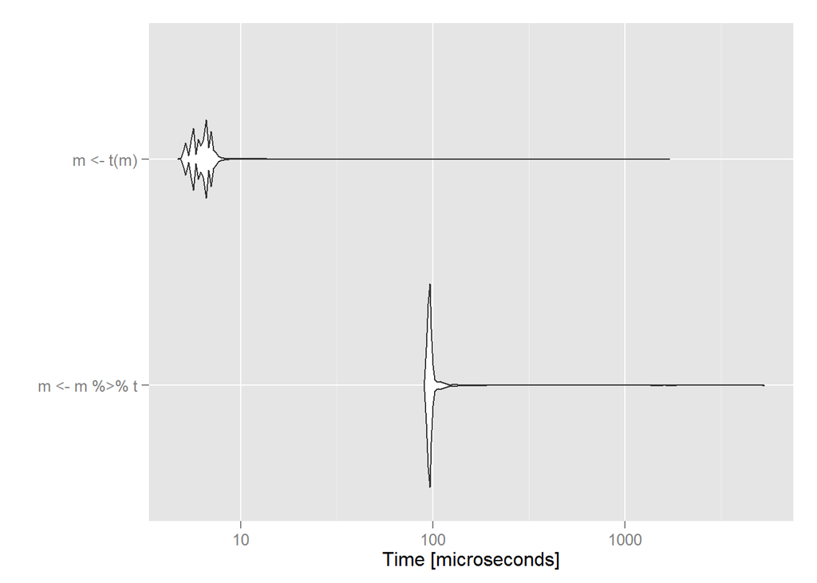

```r
autoplot(mb.dplyr)
```

```r
library(magrittr, quietly=TRUE);
mb.magrittr <- microbenchmark(
        m %<>% t,
        m <- m %>% t,
        m <- t(m),
        times=10000L
)
mb.magrittr
```

```
## Unit: microseconds
##          expr    min     lq       mean  median      uq      max neval
##      m %<>% t 92.370 97.502 104.019376 99.6005 102.167 1867.913 10000
##  m <- m %>% t 88.171 93.770 101.203364 96.1020  98.901 3134.026 10000
##     m <- t(m)  4.666  6.065   6.933159  6.5320   6.998 1478.376 10000
```

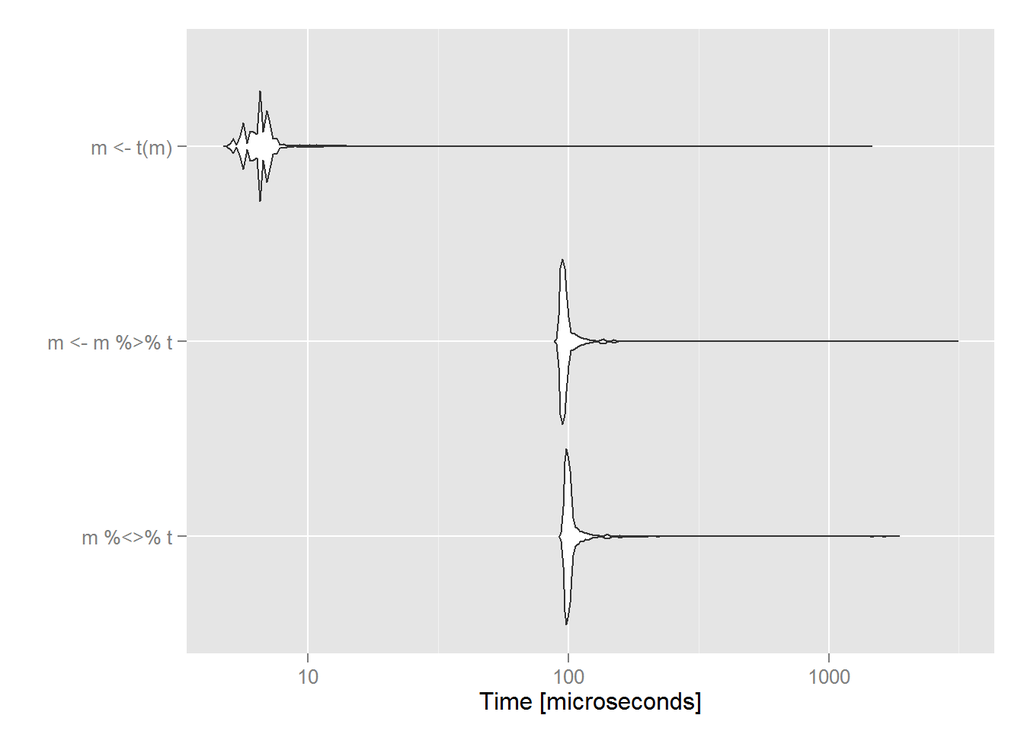

```r
autoplot(mb.magrittr)
```

## Strsplit is faster than regexp

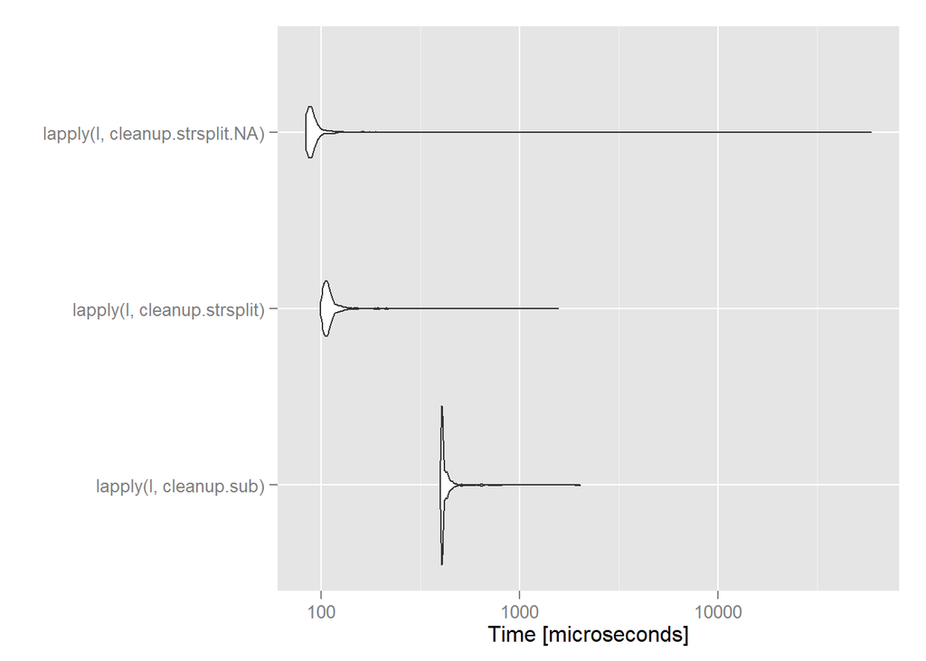

```r
cleanup.strsplit.NA <- function(s) {
        # This one is broken - it will return NA if the split isn't found
        strsplit(x=s, split="oz.) ", fixed=TRUE)[[1]][2]
}

cleanup.strsplit <- function(s) {
        s1 <- strsplit(x=s, split="oz.) ", fixed=TRUE)[[1]][2]
        if(is.na(s1)) s else s1
}

cleanup.sub <- function(s) {
        sub("(.+oz\\.\\) )(.+)", "\\2", s)
}

l <- rep(c("simple","(   oz.) tomato paste"),10)
microbenchmark(
        lapply(l,cleanup.sub),
        lapply(l,cleanup.strsplit),
        lapply(l,cleanup.strsplit.NA),
        times=1000L
        ) %>%
        autoplot
```

## row.names vs rownames

In the experiment below,

- rownames are faster for matrix for both read and write,
- it doesn’t matter for data.table and data.frame, although row.names is a bit faster

Interesingly, there’re row.names and rownames, but there’s only colnames. There’s no col.names

TODO Check if there are confidence intervals built-in in microbenchmark(), and implement, if they aren’t

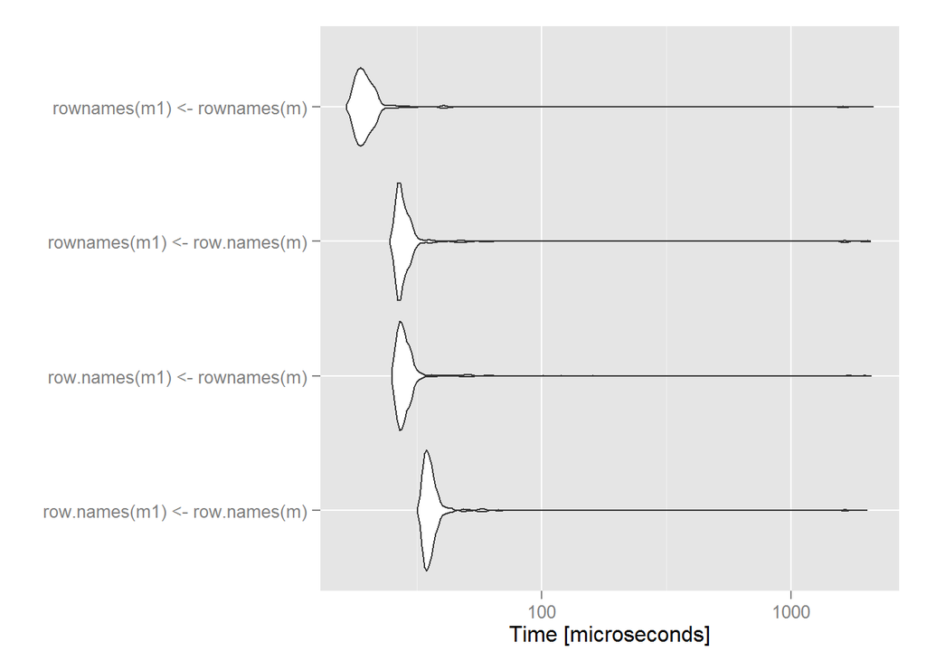

```
## Unit: microseconds
##                           expr    min     lq     mean median     uq
##  row.names(m1) <- row.names(m) 31.723 34.056 50.08752 35.455 36.855
##   row.names(m1) <- rownames(m) 24.726 26.592 39.97590 27.991 29.391
##   rownames(m1) <- row.names(m) 24.725 26.592 53.29713 27.525 28.924
##    rownames(m1) <- rownames(m) 16.328 18.195 34.55597 19.128 20.527
##       max neval
##  2017.197  1000
##  2128.693  1000
##  2087.640  1000
##  2165.548  1000
```

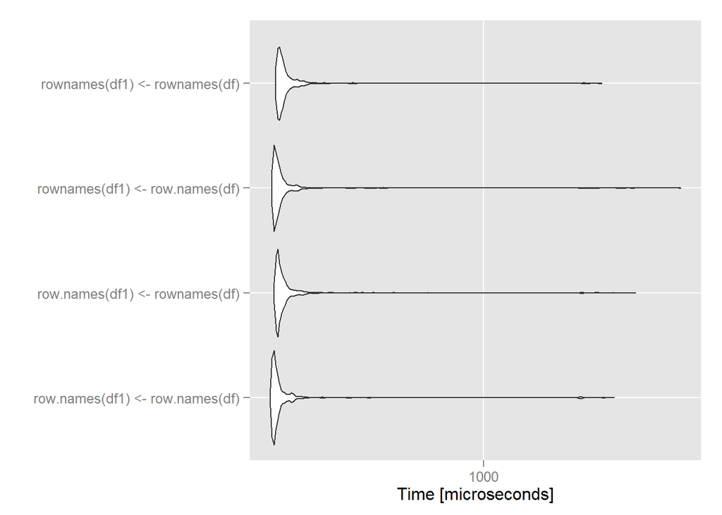

```
## Unit: microseconds
##                             expr     min      lq     mean  median       uq
##  row.names(df1) <- row.names(df) 310.697 315.829 351.9047 320.027 327.0255
##   row.names(df1) <- rownames(df) 317.695 322.827 350.2411 327.025 335.8890
##   rownames(df1) <- row.names(df) 313.030 318.161 355.6891 322.826 330.7570
##    rownames(df1) <- rownames(df) 319.095 325.626 359.4762 330.757 340.0880
##       max neval
##  2046.121  1000
##  2298.037  1000
##  2954.419  1000
##  1920.162  1000
```

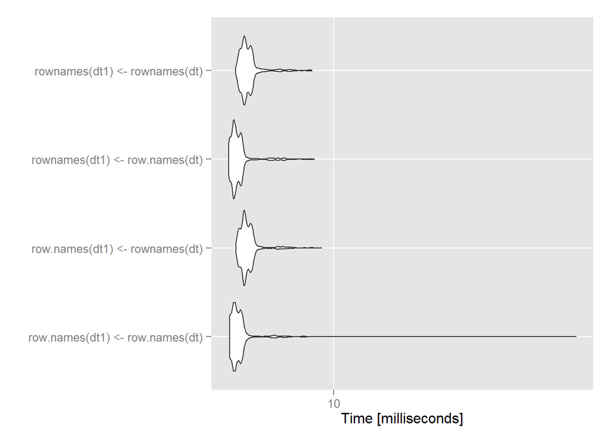

```
## Unit: milliseconds
##                             expr      min       lq     mean   median
##  row.names(dt1) <- row.names(dt) 4.605870 4.775914 5.038602 4.875748
##   row.names(dt1) <- rownames(dt) 4.869916 5.127897 5.327940 5.222132
##   rownames(dt1) <- row.names(dt) 4.610069 4.773582 4.992039 4.871549
##    rownames(dt1) <- rownames(dt) 4.856854 5.126031 5.350103 5.237994
##        uq       max neval
##  5.052556 59.611331  1000
##  5.426231  9.158558  1000
##  5.044158  8.681317  1000
##  5.435328  8.521769  1000
```

## Apply vs for loop

Technically, apply function do the same thing as for loops, but if something can be organized to be used in apply(), then it’s probably more efficient as well.

Code below calculates cuisine per receipt based on ingridient list. Probability of cuisine for each ingredient is in “weights”. First code in two variations (with pipes and not) ran for 44 and 41 seconds on list of 10k receipts, while second code (assigned to matrix from a list-based cycle) ran for 83 seconds.

Interesingly, the code below shows opposite dynamic - list is faster. A possible explanation is that apply() works better when handling large objects thousands of rows - then list-style assignment of separate values becomes the bottleneck, while on short test lists setting up higher level construct of apply() takes more time. So, again **higher level construct performs better on more complex data**, where effort spent on optimization and preparation is relatively small compared to number of following repetitions.

TODO Simulate different size of probs and tests tables - perhaps lookups and so on can be much slower for larger data and thus affect the result?

```r
probs.cut <- weights
CuisineByIngr.pipes <- function(ings) {
        cuisines[
                lapply(ings, function(y) probs.cut[y,]) %>%
                unlist %>%
                matrix(ncol=20, byrow=TRUE) %>%
                apply(2,sum) %>%
                which.max
                ]
}

CuisineByIngr.nopipes <- function(ings) {
        cuisines[
                which.max(
                        apply(
                                matrix(
                                        unlist(
                                                lapply(ings,
                                                       function(y)
                                                               probs.cut[y,]
                                                       )
                                                ),
                                        ncol=20,
                                        byrow=TRUE),
                                2,
                                sum)
                )
                ]
}

pipes <- function() re.pipes <- lapply(tests,
             function(x) c(x[[1]],
                           #CuisineByIngr.pipes(x[[2]][x[[2]] %in%ings.tr]))
                           # Original code had checks that ingredients in test
                           # list are known from train set, but it's not
                           # needed here
                           CuisineByIngr.pipes(x[[2]]))

             ) %>% unlist %>% matrix(ncol=2, byrow=TRUE)

pipesC <- function() re.pipes <- lapply(tests,
             function(x) c(x[[1]],
                CuisineByIngr.pipes(x[[2]][x[[2]] %in% rownames(probs.cut)]))
             ) %>% unlist %>% matrix(ncol=2, byrow=TRUE)

nopipes <- function() re.nopipes <- lapply(tests,
             function(x) c(x[[1]],
                           CuisineByIngr.nopipes(x[[2]]))
             ) %>% unlist %>% matrix(ncol=2, byrow=TRUE)

nopipesC <- function() re.nopipes <- lapply(tests,
             function(x) c(x[[1]],
                CuisineByIngr.nopipes(x[[2]][x[[2]] %in% rownames(probs.cut)]))
             ) %>% unlist %>% matrix(ncol=2, byrow=TRUE)

listCycle <- function() {
re.lists <- data.frame(matrix(0, nrow=length(tests), ncol=2))
blank <- rep(0,length(cuisines))
for(i in 1:length(tests)) {
        re.lists[i, 1] <- tests[[i]][[1]]
        cu.scores <- blank
        for(ing in tests[[i]][[2]])
                #if(ing %in% rownames(probs.cut)) {
                        cu.scores <- cu.scores + probs.cut[ing, ]
                #}
        re.lists[i,2] <- cuisines[which.max(cu.scores)]
}
}

listCycleC <- function() {
re.lists <- data.frame(matrix(0, nrow=length(tests), ncol=2))
blank <- rep(0,length(cuisines))
for(i in 1:length(tests)) {
        re.lists[i, 1] <- tests[[i]][[1]]
        cu.scores <- blank
        for(ing in tests[[i]][[2]])
                if(ing %in% rownames(probs.cut)) {
                        cu.scores <- cu.scores + probs.cut[ing, ]
                }
        re.lists[i,2] <- cuisines[which.max(cu.scores)]
}
}
mb <- microbenchmark(pipes(), pipesC(),
                     nopipes(), nopipesC(),
                     listCycle(), listCycleC(),
                     times=100L)
mb
```

```
## Unit: microseconds
##          expr      min        lq      mean    median        uq      max
##       pipes() 1432.192 1505.9000 1607.0773 1540.8885 1587.5400 4075.913
##      pipesC() 1470.912 1542.9880 1653.4579 1576.8100 1635.5905 4781.746
##     nopipes()  619.994  651.4840  682.7917  665.2460  699.3015 1169.546
##    nopipesC()  652.184  688.3385  713.3156  702.1005  720.7610  927.426
##   listCycle()  501.967  529.9580  576.3244  572.8770  615.0965  661.514
##  listCycleC()  653.117  696.9690  765.3362  748.9855  783.5065 3080.844
##  neval
##    100
##    100
##    100
##    100
##    100
##    100
```

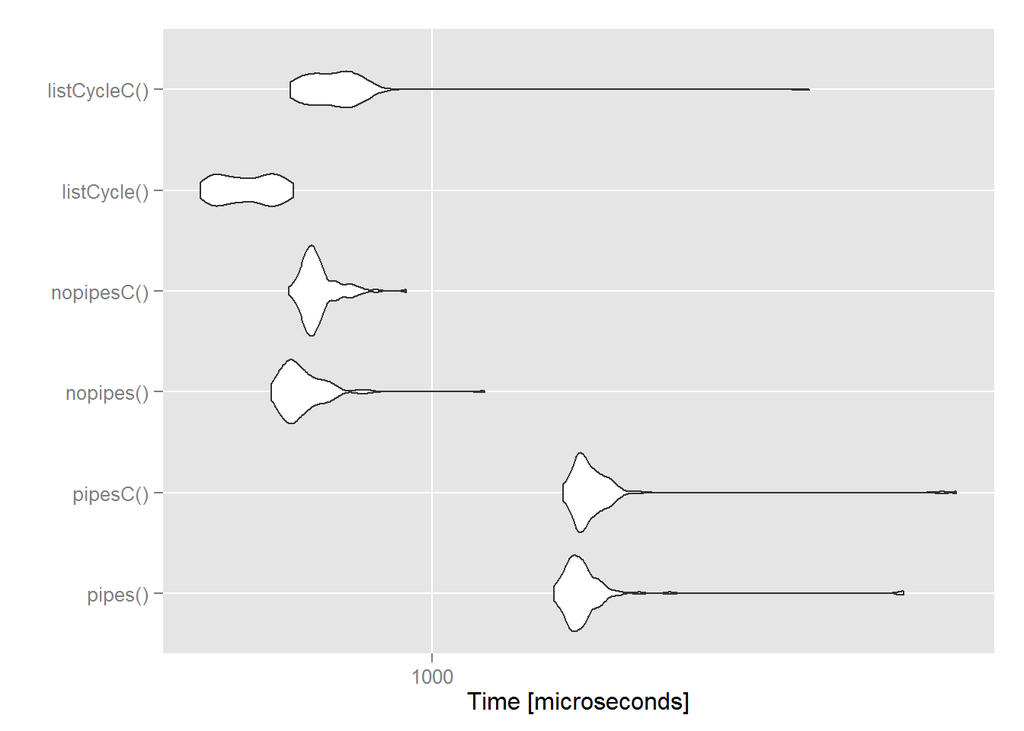

```r
autoplot(mb)
```

TODO Also add intermediate variables option